# BayWheels Dataset Exploration

## Preliminary Wrangling

This dataset contains anonymized data of approximately 300000 BayWheels bike rental in the San Francisco Bay area during January 2020.

```python
# import all packages and set plots to be embedded inline
import numpy as np
import pandas as pd
import matplotlib.pyplot as plt
import seaborn as sb

%matplotlib inline
```

```python
# loading the dataset
bike = pd.read_csv('202001-baywheels-tripdata.csv')
```

```python
# print statistics
print(bike.info())
print(bike.shape)
bike.head(10)
```

```
<class 'pandas.core.frame.DataFrame'>
RangeIndex: 295854 entries, 0 to 295853
Data columns (total 15 columns):
duration_sec               295854 non-null int64
start_time                 295854 non-null object
end_time                   295854 non-null object
start_station_id           146286 non-null float64
start_station_name         146866 non-null object
start_station_latitude     295854 non-null float64
start_station_longitude    295854 non-null float64
end_station_id             145934 non-null float64
end_station_name           146511 non-null object
end_station_latitude       295854 non-null float64
end_station_longitude      295854 non-null float64
bike_id                    295854 non-null int64
user_type                  295854 non-null object
bike_share_for_all_trip    110108 non-null object
rental_access_method       185746 non-null object
dtypes: float64(6), int64(2), object(7)
memory usage: 33.9+ MB
None
(295854, 15)
```

|  | duration_sec | start_time | end_time | start_station_id | start_station_name | start_station_latitude | start_station_longitude | end_station_id | end_station_name | end_station_latitude | end_station_longitude | bike_id | user_type | bike_share_for_all_trip | rental_access_method |
| --- | --- | --- | --- | --- | --- | --- | --- | --- | --- | --- | --- | --- | --- | --- | --- |
| 0 | 83118 | 2020-01-31 15:23:47.7330 | 2020-02-01 14:29:06.2630 | 400.0 | Buchanan St at North Point St | 37.804272 | -122.433537 | 400.0 | Buchanan St at North Point St | 37.804272 | -122.433537 | 13052 | Customer | No | NaN |
| 1 | 68239 | 2020-01-31 15:40:31.6160 | 2020-02-01 10:37:51.0000 | 99.0 | Folsom St at 15th St | 37.767037 | -122.415443 | 99.0 | Folsom St at 15th St | 37.767037 | -122.415443 | 12235 | Subscriber | Yes | NaN |
| 2 | 55407 | 2020-01-31 17:48:16.6350 | 2020-02-01 09:11:44.3170 | 197.0 | El Embarcadero at Grand Ave | 37.808848 | -122.249680 | 197.0 | El Embarcadero at Grand Ave | 37.808848 | -122.249680 | 12822 | Customer | No | NaN |
| 3 | 54929 | 2020-01-31 17:53:03.4130 | 2020-02-01 09:08:32.6340 | 197.0 | El Embarcadero at Grand Ave | 37.808848 | -122.249680 | 197.0 | El Embarcadero at Grand Ave | 37.808848 | -122.249680 | 11705 | Customer | No | NaN |
| 4 | 55700 | 2020-01-31 17:12:33.4600 | 2020-02-01 08:40:53.6460 | 12.0 | Pier 1/2 at The Embarcadero | 37.796389 | -122.394586 | 371.0 | Lombard St at Columbus Ave | 37.802746 | -122.413579 | 3673 | Customer | No | NaN |
| 5 | 11333 | 2020-01-31 22:48:22.6390 | 2020-02-01 01:57:15.7160 | 60.0 | 8th St at Ringold St | 37.774520 | -122.409449 | 75.0 | Market St at Franklin St | 37.773793 | -122.421239 | 12137 | Customer | No | NaN |
| 6 | 11341 | 2020-01-31 22:48:12.9890 | 2020-02-01 01:57:14.1650 | 60.0 | 8th St at Ringold St | 37.774520 | -122.409449 | 75.0 | Market St at Franklin St | 37.773793 | -122.421239 | 12321 | Customer | No | NaN |
| 7 | 4038 | 2020-01-31 23:32:03.9070 | 2020-02-01 00:39:22.0210 | 450.0 | Funston Ave at Irving St | 37.763934 | -122.470651 | 450.0 | Funston Ave at Irving St | 37.763934 | -122.470651 | 1589 | Customer | No | NaN |
| 8 | 4059 | 2020-01-31 23:31:01.1610 | 2020-02-01 00:38:40.8570 | 450.0 | Funston Ave at Irving St | 37.763934 | -122.470651 | 450.0 | Funston Ave at Irving St | 37.763934 | -122.470651 | 12884 | Customer | No | NaN |
| 9 | 1980 | 2020-01-31 23:49:09.2300 | 2020-02-01 00:22:09.7540 | 238.0 | MLK Jr Way at University Ave | 37.871719 | -122.273068 | 198.0 | Snow Park | 37.807813 | -122.264496 | 10464 | Customer | No | NaN |

```python
# descriptive statistics
bike.describe()
```

|  | duration_sec | start_station_id | start_station_latitude | start_station_longitude | end_station_id | end_station_latitude | end_station_longitude | bike_id |
| --- | --- | --- | --- | --- | --- | --- | --- | --- |
| count | 295854.000000 | 146286.000000 | 295854.000000 | 295854.000000 | 145934.000000 | 295854.000000 | 295854.000000 | 295854.00000 |
| mean | 780.473193 | 168.900879 | 37.751277 | -122.357866 | 161.061788 | 37.751261 | -122.356994 | 321533.84539 |
| std | 2037.786317 | 141.956388 | 0.228337 | 0.650796 | 140.766154 | 0.238642 | 0.688512 | 307015.31534 |
| min | 60.000000 | 3.000000 | 0.000000 | -122.513871 | 3.000000 | 0.000000 | -122.513847 | 12.00000 |
| 25% | 369.000000 | 53.000000 | 37.766214 | -122.419481 | 43.000000 | 37.766376 | -122.418306 | 11328.00000 |
| 50% | 588.000000 | 120.000000 | 37.777158 | -122.403234 | 113.000000 | 37.777370 | -122.402717 | 279974.00000 |
| 75% | 912.000000 | 263.000000 | 37.790102 | -122.392450 | 250.000000 | 37.790492 | -122.392546 | 545607.00000 |
| max | 811077.000000 | 506.000000 | 37.880222 | 0.000000 | 506.000000 | 37.927622 | 0.000000 | 999952.00000 |

### What is the structure of your dataset?

There are 295854 rentals from 01/01/2020 to 31/01/2020. Not every feature have complete data. Complete feature are: rental duration, beginning and end of rental, start station and end station coordinates (latitude and longitude), id of rented bike and user type (subscriber or customer).

### What is/are the main feature(s) of interest in your dataset?

I want to figure the main use of bike rental by people looking at day and hour of usage and possibly other characteristics.

### What features in the dataset do you think will help support your investigation into your feature(s) of interest?

Having complete data of date/time will help finding the trends of rentals. Also, coordinates can give useful geographical insights.

## Univariate Exploration

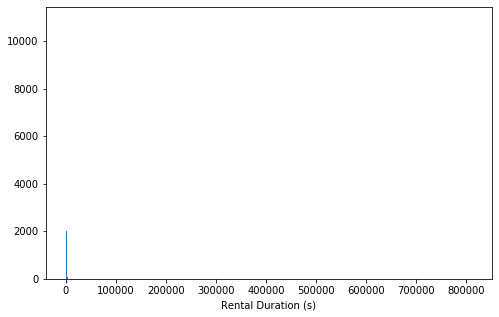

```python
#plot of duration of the entire dataset
binsize = 30
bins = np.arange(0, bike['duration_sec'].max()+binsize, binsize)

plt.figure(figsize=[8, 5])
plt.hist(data = bike, x = 'duration_sec', bins = bins)
plt.xlabel('Rental Duration (s)')
plt.show();
```

```python
#estimate number of the outliers
print(bike[bike['duration_sec']>3600].shape)
print(bike[bike['duration_sec']<=3600].shape)
```

```
(3325, 15)
(292529, 15)
```

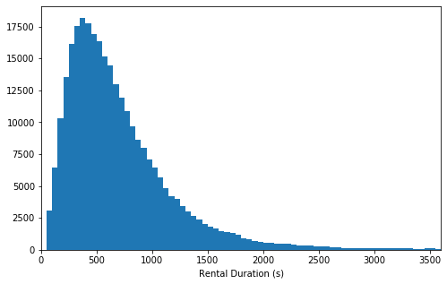

```python
#limiting x axis to remove outliers
binsize = 50
bins = np.arange(0, bike['duration_sec'].max()+binsize, binsize)

plt.figure(figsize=[8, 5])
plt.hist(data = bike, x = 'duration_sec', bins = bins)
plt.xlim([0 , 3600])
plt.xlabel('Rental Duration (s)')
plt.show();
```

Rental duration, while it's true that has a long tailed distribution, highlight a peak in short-term rentals below 500 seconds. On average, considering a speed on a bike at 25 km/h, in 10 minutes a distance of 4 km is covered. This means that the majority of rentals are for short-term, short distance trip.

Next, we'll look at the temporal analysis of rentals. Before the analysis a little feature engineering (and wrangling) is done.

```python
bike[['start_time_date','start_time_hour']] = bike['start_time'].str.split(' ', expand = True)
```

```python
bike[['end_time_date','end_time_hour']] = bike['end_time'].str.split(' ', expand = True)
```

```python
bike['start_time_date'] = pd.to_datetime(bike['start_time_date'])
```

```python
bike['end_time_date'] = pd.to_datetime(bike['end_time_date'])
```

```python
bike['start_time_hour'] = bike['start_time_hour'].str.split(':',expand = True)[0]
```

```python
bike['end_time_hour'] = bike['end_time_hour'].str.split(':',expand = True)[0]
```

```python
bike['start_dayname'] = bike['start_time_date'].dt.day_name()
```

```python
bike['end_dayname'] = bike['end_time_date'].dt.day_name()
```

```python
bike['start_time_date'] = pd.to_datetime(bike['start_time_date']).dt.date
```

```python
bike['end_time_date'] = pd.to_datetime(bike['end_time_date']).dt.date
```

Considering that we have start and end of rentals timestamps, i want to look at eventual difference between distributions.

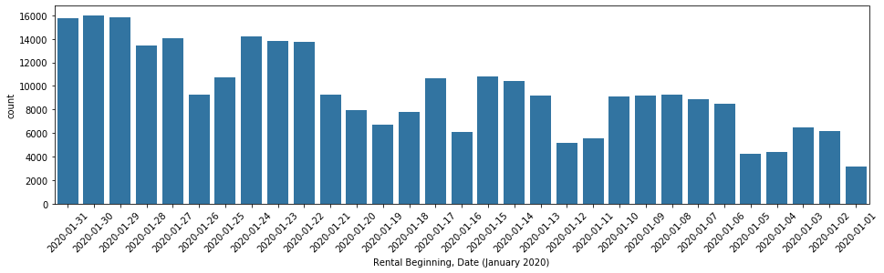

```python
#Rental beginning by date
plt.figure(figsize = [16, 4])
default_color = sb.color_palette()[0]
sb.countplot(data = bike, x = 'start_time_date', color = default_color)
plt.xlabel('Rental Beginning, Date (January 2020)')
plt.xticks(rotation = 45);
```

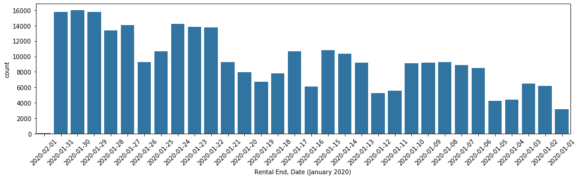

```python
#Rental end by date
plt.figure(figsize = [16, 4])
default_color = sb.color_palette()[0]
sb.countplot(data = bike, x = 'end_time_date', color = default_color)
plt.xlabel('Rental End, Date (January 2020)')
plt.xticks(rotation = 45);
```

Looking at the distribution of start and end of rental, they are extremely similar, both in number than in proportion. They have a distinct pattern of 5 days of "high" number of rental followed by 2 days of "low" number of rental. It is higly probable that this difference is due to work days and weekends.

Consider now the same temporal analysis but based on the day of the week, as suggested by the previous distributions.

```python
ordinal_var = ['Monday','Tuesday','Wednesday','Thursday','Friday','Saturday','Sunday']
ordered_var = pd.api.types.CategoricalDtype(ordered = True, categories = ordinal_var)
bike['start_dayname'] = bike['start_dayname'].astype(ordered_var)
bike['end_dayname'] = bike['start_dayname'].astype(ordered_var)
```

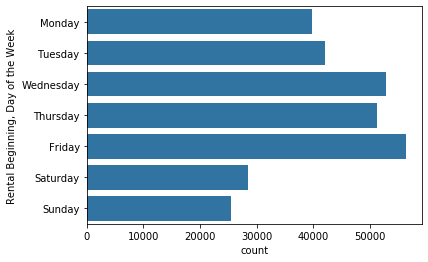

```python
#Rental beginning by day of the week
default_color = sb.color_palette()[0]
sb.countplot(data = bike, y = 'start_dayname', color = default_color)
plt.ylabel('Rental Beginning, Day of the Week');
```

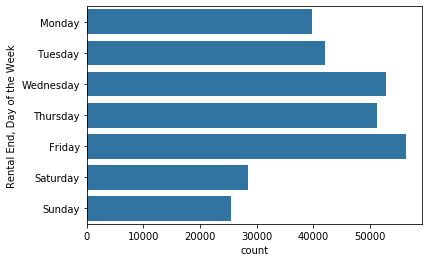

```python
#Rental end by day of the week
default_color = sb.color_palette()[0]
sb.countplot(data = bike, y = 'end_dayname', color = default_color)
plt.ylabel('Rental End, Day of the Week');
```

As predicted, work days have an higher number of rentals. Like the previous distribution of start and end of rental during the month, also the distribution by the day of the week for start is similar to the end of rental.

To conclude the temporal analysis, we now look at the hours of the day where rentals are more common.

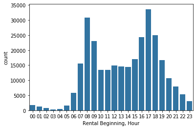

```python
default_color = sb.color_palette()[0]
sb.countplot(data = bike, x = 'start_time_hour', color = default_color)
plt.xlabel('Rental Beginning, Hour');
```

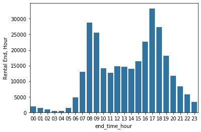

```python
default_color = sb.color_palette()[0]
sb.countplot(data = bike, x = 'end_time_hour', color = default_color)
plt.ylabel('Rental End, Hour');
```

Looking at those distribution we see distinct peak at 08:00-09:00 and 17:00-18:00. This means that commonly the rentals are made on workdays for commuting. Like previous distributions, there's no real difference between start and end of rental.

For an easier analysis, taking into account the similarities between beginning and end of rental, i want to consider just one case of the two available. Of the two, i choose the end of rentals.

The next part of univariate analysis will look at the geographical distribution of rentals in the San Francisco Bay.

*Note 1 to reviewer*  
*As suggested by my mentor, a nice visualization of the coordinates can be made using gmaps API. Unfortunately, it is no longer available for free so i opted for a "classic" heatmap.*

*Note 2 to reviewer*  
*While it is true that, technically, this analysis is not univariate, it is also impossible to conceive an analysis by coordinates using only longitude and/or latitude. For this reason i consider the complete variable as "start station coordinates" and "end station coordinates"*

As seen in the preliminary description of the dataset, some coordinates are at a latitude or longitude of zero. I decided to drop those rows.

```python
bike = bike.drop(bike[bike['start_station_longitude'] == 0].index)
bike = bike.drop(bike[bike['start_station_latitude'] == 0].index)
bike = bike.drop(bike[bike['end_station_longitude'] == 0].index)
bike = bike.drop(bike[bike['end_station_latitude'] == 0].index)
```

```python
bike.describe()
```

|  | duration_sec | start_station_id | start_station_latitude | start_station_longitude | end_station_id | end_station_latitude | end_station_longitude | bike_id |
| --- | --- | --- | --- | --- | --- | --- | --- | --- |
| count | 295837.000000 | 146270.000000 | 295837.000000 | 295837.000000 | 145925.000000 | 295837.000000 | 295837.000000 | 295837.000000 |
| mean | 779.611888 | 168.885308 | 37.752297 | -122.361174 | 161.044029 | 37.752410 | -122.360716 | 321535.689140 |
| std | 2024.396358 | 141.944560 | 0.116621 | 0.136714 | 140.752330 | 0.116600 | 0.136393 | 307014.418756 |
| min | 60.000000 | 3.000000 | 37.275291 | -122.513871 | 3.000000 | 37.258978 | -122.513847 | 12.000000 |
| 25% | 369.000000 | 53.000000 | 37.766216 | -122.419482 | 43.000000 | 37.766379 | -122.418307 | 11328.000000 |
| 50% | 588.000000 | 120.000000 | 37.777159 | -122.403234 | 113.000000 | 37.777374 | -122.402717 | 279974.000000 |
| 75% | 912.000000 | 263.000000 | 37.790102 | -122.392452 | 250.000000 | 37.790493 | -122.392549 | 545607.000000 |
| max | 811077.000000 | 506.000000 | 37.880222 | -121.809475 | 506.000000 | 37.927622 | -121.772722 | 999952.000000 |

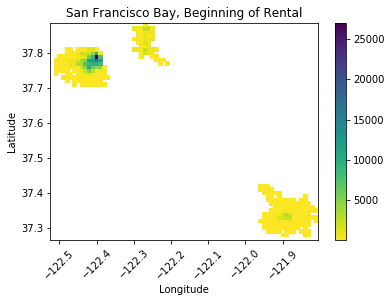

```python
binsize = 0.01

plt.title('San Francisco Bay, Beginning of Rental')

bins_x = np.arange(bike['start_station_longitude'].min()-binsize, bike['start_station_longitude'].max()+binsize, binsize)
bins_y = np.arange(bike['start_station_latitude'].min()-binsize, bike['start_station_latitude'].max()+binsize, binsize)

plt.hist2d(data = bike, x = 'start_station_longitude', y = 'start_station_latitude', bins = [bins_x, bins_y], cmap = 'viridis_r', cmin = 1)
plt.xlabel('Longitude')
plt.ylabel('Latitude')
plt.xticks(rotation = 45)
plt.colorbar();
```

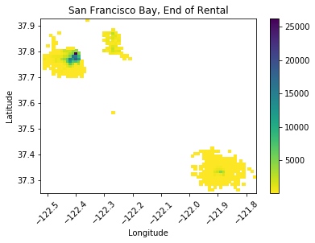

```python
binsize = 0.01

plt.title('San Francisco Bay, End of Rental')

bins_x = np.arange(bike['end_station_longitude'].min()-binsize, bike['end_station_longitude'].max()+binsize, binsize)
bins_y = np.arange(bike['end_station_latitude'].min()-binsize, bike['end_station_latitude'].max()+binsize, binsize)

plt.hist2d(data = bike, x = 'end_station_longitude', y = 'end_station_latitude', bins = [bins_x, bins_y], cmap = 'viridis_r', cmin = 1)
plt.xlabel('Longitude')
plt.ylabel('Latitude')
plt.xticks(rotation = 45)
plt.colorbar();
```

All the rentals are concentrated in three distinct city, from left to right: San Francisco, Oakland and San Jose.  
I want to look now if it is possible that some rentals begins and ends in different cities.

```python
san_francisco = bike[bike['start_station_longitude'].between(bike['start_station_longitude'].min(), -122.35, inclusive=True)]
oakland = bike[bike['start_station_longitude'].between(-122.35, -122.15, inclusive=True)]
san_jose = bike[bike['start_station_longitude'].between(-122.00, bike['start_station_longitude'].max(), inclusive=True)]
```

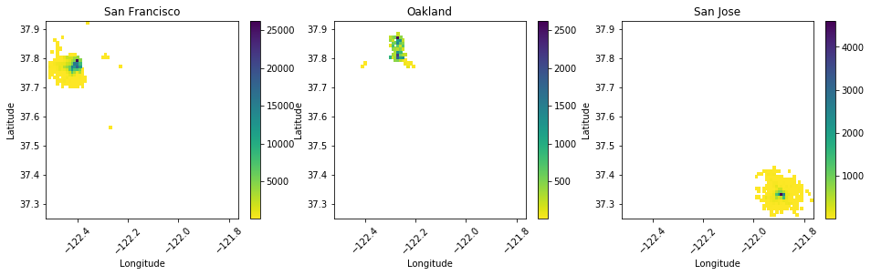

```python
binsize = 0.01

bins_x = np.arange(bike['end_station_longitude'].min()-binsize, bike['end_station_longitude'].max()+binsize, binsize)
bins_y = np.arange(bike['end_station_latitude'].min()-binsize, bike['end_station_latitude'].max()+binsize, binsize)

plt.figure(figsize = [16, 4])

plt.subplot(1,3,1)
plt.title('San Francisco')
plt.hist2d(data = san_francisco, x = 'end_station_longitude', y = 'end_station_latitude', bins = [bins_x, bins_y], cmap = 'viridis_r', cmin = 1)
plt.xlabel('Longitude')
plt.ylabel('Latitude')
plt.xticks(rotation = 45)
plt.colorbar();

plt.subplot(1,3,2)
plt.title('Oakland')
plt.hist2d(data = oakland, x = 'end_station_longitude', y = 'end_station_latitude', bins = [bins_x, bins_y], cmap = 'viridis_r', cmin = 1)
plt.xlabel('Longitude')
plt.ylabel('Latitude')
plt.xticks(rotation = 45)
plt.colorbar();

plt.subplot(1,3,3)
plt.title('San Jose')
plt.hist2d(data = san_jose, x = 'end_station_longitude', y = 'end_station_latitude', bins = [bins_x, bins_y], cmap = 'viridis_r', cmin = 1)
plt.xlabel('Longitude')
plt.ylabel('Latitude')
plt.xticks(rotation = 45)
plt.colorbar();
```

Restricting datasets to the three cities by the beginning of rentals and plotting the heatmap of the end of those rentals we see that they are circumscribed in the same cities.  
San Francisco, for example, have an area of 122 km^2 and thus a radius of around 6 km. Considering what we said about the average rental duration it is another evidence that rentals are short-term and short distance and done by workers.

Talking about users of BayWheels, let's see what type they are.

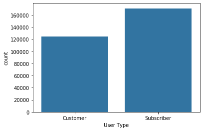

```python
default_color = sb.color_palette()[0]
sb.countplot(data = bike, x = 'user_type', color = default_color)
plt.xlabel('User Type');
```

Subscriber are around 30% more than "simple" Customers.

### Discuss the distribution(s) of your variable(s) of interest. Were there any unusual points? Did you need to perform any transformations?

The distribution of my variables of interest is pretty clear, with no trasformation needed to understand them.

### Of the features you investigated, were there any unusual distributions? Did you perform any operations on the data to tidy, adjust, or change the form of the data? If so, why did you do this?

The rental duration distribution had some outliers and i had to limit the distribution to rentals shorter than 3600 seconds. Datas were strings and not datetime and i created columns for the day of the month, corresponding day of the week and hour of rental to do temporal analysis of the dataset.  
Coordinates have some erroneous data (coordinates at (0,0), https://it.wikipedia.org/wiki/Null_Island) and were dropped before the geographical analysis.

## Bivariate Exploration

First of all, let's see the distribution on each day of the week of the end of rentals.

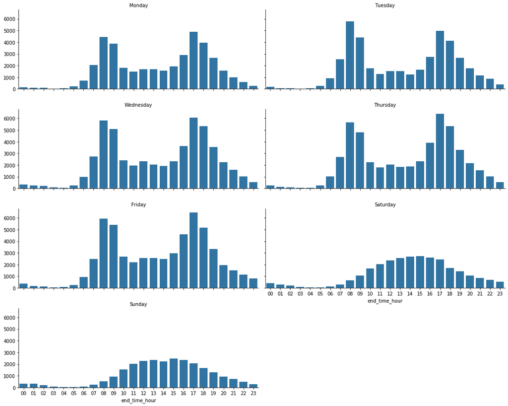

```python
def countplot(x, **kwargs):
    sb.countplot(x=x, **kwargs)

grid = sb.FacetGrid(data=bike,col='end_dayname', aspect = 2.5, col_wrap = 2)
grid.map(countplot,'end_time_hour')
grid.set_titles('{col_name}');
```

Right now, with this plot, it is quite evident that not only the rentals are more frequent on workdays but also that the hours of rental are just around the beginning and end of workday! In fact, on Saturday and Sunday, whithout those peaks the distribution takes a more "normal" approach of an increase of rentals during the day and a decrease during the night.

This can be emphasized with a rental day of the week to rental hour heatmap.

```python
dayhour_counts = bike.groupby(['end_dayname', 'end_time_hour']).size().to_frame('count')
dayhour_counts = dayhour_counts.reset_index()
dayhour_counts = dayhour_counts.pivot(index = 'end_time_hour', columns = 'end_dayname', values = 'count')
```

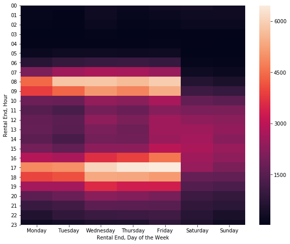

```python
plt.figure(figsize = [10, 8])
sb.heatmap(dayhour_counts)
plt.yticks(rotation = 0)
plt.xlabel('Rental End, Day of the Week')
plt.ylabel('Rental End, Hour');
```

Finally, let's see if there's some kind of correlation between rental day of the week and duration of those rentals.

```python
bike_lim = bike[bike['duration_sec'].between(0,3600)]
```

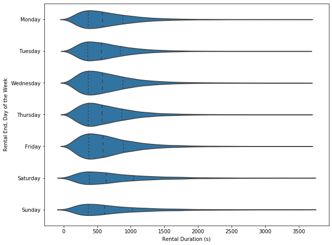

```python
plt.figure(figsize = [10, 8])

default_color = sb.color_palette()[0]
sb.violinplot(data = bike_lim, y = 'end_dayname', x = 'duration_sec', color = default_color, inner = 'quartile', scale='count')
plt.xlabel('Rental Duration (s)')
plt.ylabel('Rental End, Day of the Week');
```

Areas of violin on each days is proportional to the number of rental. While it is evident that on weekends the rentals are much lower, they present similar distribution of rental duration.

### Talk about some of the relationships you observed in this part of the investigation. How did the feature(s) of interest vary with other features in the dataset?

As expected, rentals are much common during workdays and on 8:00-9:00 and 17:00-18:00 (the hours where, usually, people begin and end their job).

### Did you observe any interesting relationships between the other features (not the main feature(s) of interest)?

I was expecting a more marked difference in rental duration during weekends but actually they were similar, just much lower in numbers.

## Multivariate Exploration

In the bivariate section we saw that, based on different days of the week, we have more rentals during workdays than weekends. How this difference behaves in the three different cities were those rentals are done?

To analyze the three cities, i have restricted the bins around longitude and latitude coordinates.

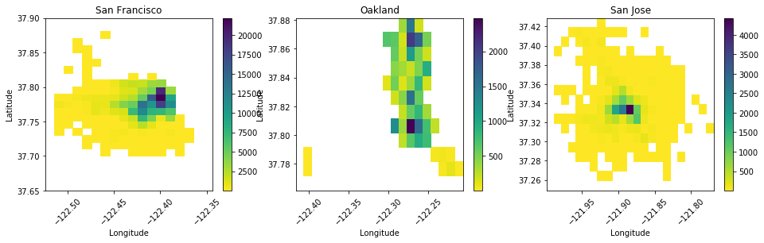

```python
binsize = 0.01


plt.figure(figsize = [16, 4])

plt.subplot(1,3,1)
plt.title('San Francisco')
bins_x = np.arange(san_francisco['end_station_longitude'].min()-binsize, -122.35+binsize, binsize)
bins_y = np.arange(37.65, 37.90+binsize, binsize)
plt.hist2d(data = san_francisco, x = 'end_station_longitude', y = 'end_station_latitude', bins = [bins_x, bins_y], cmap = 'viridis_r', cmin = 1)
plt.xticks(rotation = 45)
plt.xlabel('Longitude')
plt.ylabel('Latitude')
plt.colorbar()

plt.subplot(1,3,2)
plt.title('Oakland')
bins_x = np.arange(oakland['end_station_longitude'].min()-binsize, oakland['end_station_longitude'].max()+binsize, binsize)
bins_y = np.arange(oakland['end_station_latitude'].min()-binsize, oakland['end_station_latitude'].max()+binsize, binsize)
plt.hist2d(data = oakland, x = 'end_station_longitude', y = 'end_station_latitude', bins = [bins_x, bins_y], cmap = 'viridis_r', cmin = 1)
plt.xticks(rotation = 45)
plt.xlabel('Longitude')
plt.ylabel('Latitude')
plt.colorbar()

plt.subplot(1,3,3)
plt.title('San Jose')
bins_x = np.arange(san_jose['end_station_longitude'].min()-binsize, san_jose['end_station_longitude'].max()+binsize, binsize)
bins_y = np.arange(san_jose['end_station_latitude'].min()-binsize, san_jose['end_station_latitude'].max()+binsize, binsize)
plt.hist2d(data = san_jose, x = 'end_station_longitude', y = 'end_station_latitude', bins = [bins_x, bins_y], cmap = 'viridis_r', cmin = 1)
plt.xticks(rotation = 45)
plt.xlabel('Longitude')
plt.ylabel('Latitude')
plt.colorbar();
```

```python
binsize = 0.01
def hist2dgrid(x, y, lim, bins, **kwargs):
    plt.hist2d(x, y, bins = [bins_x, bins_y], cmap = 'viridis_r', cmin = 0.5)
    plt.clim(0,lim)
    plt.xticks(rotation = 45)
    plt.colorbar()
```

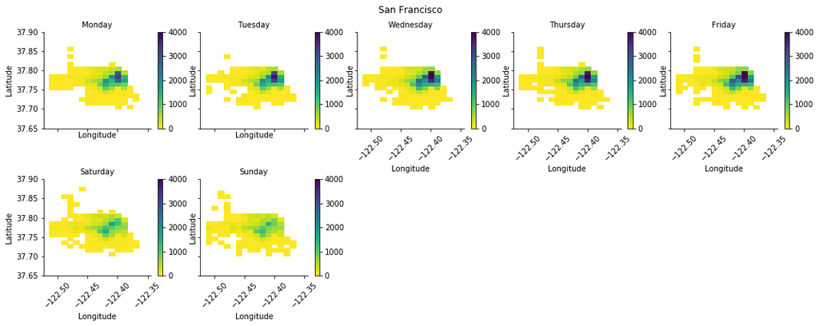

```python
bins_x = np.arange(san_francisco['end_station_longitude'].min()-binsize, -122.35+binsize, binsize)
bins_y = np.arange(37.65, 37.90+binsize, binsize)
g = sb.FacetGrid(data = san_francisco, col = 'end_dayname', col_wrap = 5, height = 3,)
g.map(hist2dgrid, 'end_station_longitude', 'end_station_latitude', lim = 4000,  bins = [bins_x, bins_y] )
plt.subplots_adjust(top=0.9)
g.fig.suptitle('San Francisco')
g.set_titles('{col_name}')
for n in range(0,7):
    g.axes[n].set_xlabel('Longitude')
    g.axes[n].set_ylabel('Latitude')
plt.show()
```

Taking into account the behaviour during workdays we previously saw, San Francisco follows it neatly.

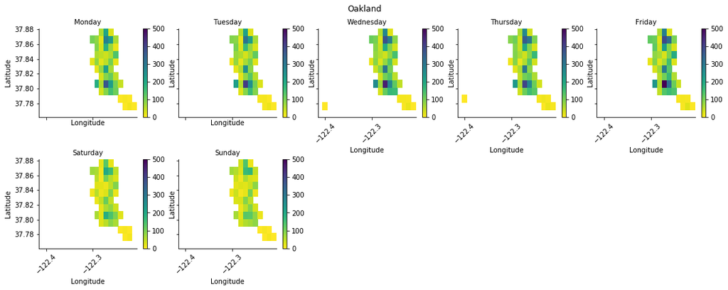

```python
bins_x = np.arange(oakland['end_station_longitude'].min()-binsize, oakland['end_station_longitude'].max()+binsize, binsize)
bins_y = np.arange(oakland['end_station_latitude'].min()-binsize, oakland['end_station_latitude'].max()+binsize, binsize)
g = sb.FacetGrid(data = oakland, col = 'end_dayname', col_wrap = 5, height = 3,)
g.map(hist2dgrid, 'end_station_longitude', 'end_station_latitude', lim = 500, bins = [bins_x, bins_y] )
plt.subplots_adjust(top=0.9)
g.fig.suptitle('Oakland')
g.set_titles('{col_name}')
for n in range(0,7):
    g.axes[n].set_xlabel('Longitude')
    g.axes[n].set_ylabel('Latitude')
plt.show()
```

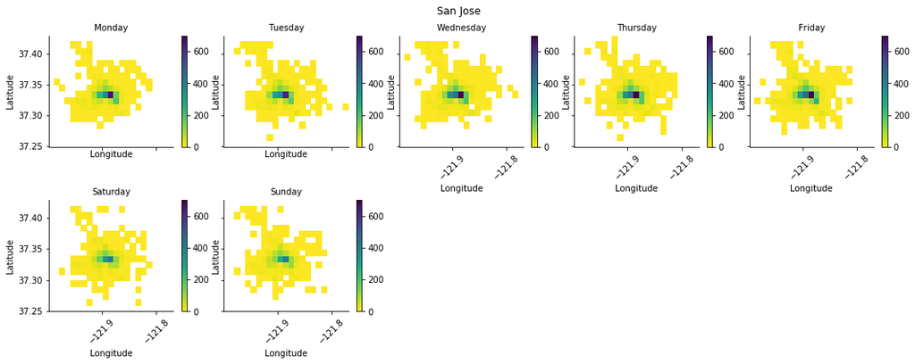

```python
bins_x = np.arange(san_jose['end_station_longitude'].min()-binsize, san_jose['end_station_longitude'].max()+binsize, binsize)
bins_y = np.arange(san_jose['end_station_latitude'].min()-binsize, san_jose['end_station_latitude'].max()+binsize, binsize)
g = sb.FacetGrid(data = san_jose, col = 'end_dayname', col_wrap = 5, height = 3,)
g.map(hist2dgrid, 'end_station_longitude', 'end_station_latitude', lim = 700, bins = [bins_x, bins_y] )
plt.subplots_adjust(top=0.9)
g.fig.suptitle('San Jose')
g.set_titles('{col_name}')
for n in range(0,7):
    g.axes[n].set_xlabel('Longitude')
    g.axes[n].set_ylabel('Latitude')
plt.show()
```

Also Oakland and San Jose follows the workdays-weekend axiom.

A a final part of the multivariate exploration, i want to look at what type of user rents BayWheels bike at San Francisco, Oakland and San Jose.

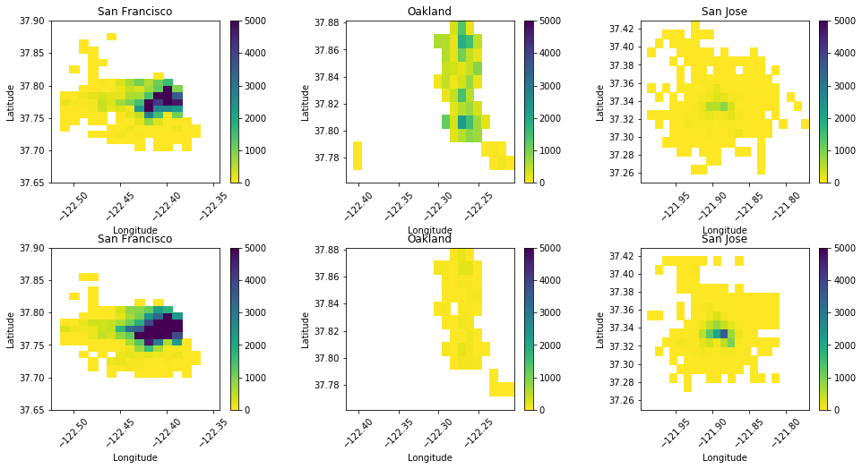

```python
binsize = 0.01
lim = 5000

plt.figure(figsize = [16, 8])


plt.subplot(2,3,1)
plt.title('San Francisco')
bins_x = np.arange(san_francisco['end_station_longitude'].min()-binsize, -122.35+binsize, binsize)
bins_y = np.arange(37.65, 37.90+binsize, binsize)
plt.hist2d(data = san_francisco[san_francisco['user_type'] == 'Customer'], x = 'end_station_longitude', y = 'end_station_latitude', bins = [bins_x, bins_y], cmap = 'viridis_r', cmin = 1)
plt.clim(0,lim)
plt.xticks(rotation = 45)
plt.xlabel('Longitude')
plt.ylabel('Latitude')
plt.colorbar()

plt.subplot(2,3,2)
plt.title('Oakland')
bins_x = np.arange(oakland['end_station_longitude'].min()-binsize, oakland['end_station_longitude'].max()+binsize, binsize)
bins_y = np.arange(oakland['end_station_latitude'].min()-binsize, oakland['end_station_latitude'].max()+binsize, binsize)
plt.hist2d(data = oakland[oakland['user_type'] == 'Customer'], x = 'end_station_longitude', y = 'end_station_latitude', bins = [bins_x, bins_y], cmap = 'viridis_r', cmin = 1)
plt.clim(0,lim)
plt.xticks(rotation = 45)
plt.xlabel('Longitude')
plt.ylabel('Latitude')
plt.colorbar()

plt.subplot(2,3,3)
plt.title('San Jose')
bins_x = np.arange(san_jose['end_station_longitude'].min()-binsize, san_jose['end_station_longitude'].max()+binsize, binsize)
bins_y = np.arange(san_jose['end_station_latitude'].min()-binsize, san_jose['end_station_latitude'].max()+binsize, binsize)
plt.hist2d(data = san_jose[san_jose['user_type'] == 'Customer'], x = 'end_station_longitude', y = 'end_station_latitude', bins = [bins_x, bins_y], cmap = 'viridis_r', cmin = 1)
plt.clim(0,lim)
plt.xticks(rotation = 45)
plt.xlabel('Longitude')
plt.ylabel('Latitude')
plt.colorbar()

plt.subplot(2,3,4)
plt.title('San Francisco')
bins_x = np.arange(san_francisco['end_station_longitude'].min()-binsize, -122.35+binsize, binsize)
bins_y = np.arange(37.65, 37.90+binsize, binsize)
plt.hist2d(data = san_francisco[san_francisco['user_type'] == 'Subscriber'], x = 'end_station_longitude', y = 'end_station_latitude', bins = [bins_x, bins_y], cmap = 'viridis_r', cmin = 1)
plt.clim(0,lim)
plt.xticks(rotation = 45)
plt.xlabel('Longitude')
plt.ylabel('Latitude')
plt.colorbar()

plt.subplot(2,3,5)
plt.title('Oakland')
bins_x = np.arange(oakland['end_station_longitude'].min()-binsize, oakland['end_station_longitude'].max()+binsize, binsize)
bins_y = np.arange(oakland['end_station_latitude'].min()-binsize, oakland['end_station_latitude'].max()+binsize, binsize)
plt.hist2d(data = oakland[oakland['user_type'] == 'Subscriber'], x = 'end_station_longitude', y = 'end_station_latitude', bins = [bins_x, bins_y], cmap = 'viridis_r', cmin = 1)
plt.clim(0,lim)
plt.xticks(rotation = 45)
plt.xlabel('Longitude')
plt.ylabel('Latitude')
plt.colorbar()

plt.subplot(2,3,6)
plt.title('San Jose')
bins_x = np.arange(san_jose['end_station_longitude'].min()-binsize, san_jose['end_station_longitude'].max()+binsize, binsize)
bins_y = np.arange(san_jose['end_station_latitude'].min()-binsize, san_jose['end_station_latitude'].max()+binsize, binsize)
plt.hist2d(data = san_jose[san_jose['user_type'] == 'Subscriber'], x = 'end_station_longitude', y = 'end_station_latitude', bins = [bins_x, bins_y], cmap = 'viridis_r', cmin = 1)
plt.clim(0,lim)
plt.xticks(rotation = 45)
plt.xlabel('Longitude')
plt.ylabel('Latitude')
plt.colorbar()

plt.subplots_adjust(wspace=0.4, hspace=0.4);
```

Surprinsingly, in Oakland is more common that a Customer rent a BayWheel bike than a Subscriber one. With the data i have on hand it is not possible to motivate this different behaviour: maybe is just that San Francisco and San Jose users are more fidelized and oriented to a subscriber type of account (and thus a more frequent use of BayWheels bike looking at previous exploration) and Oakland users are more "new" to this service. Or maybe, users from Oakland sometimes (and not sistematically) rent bikes to go to Berkeley University and do not "suffer" of commuting because of university dormitories (note: here in Italy we have a different system for Unviersity and dormitories are rare so i'm just guessing).

Lastly, i want to understand the relationship between user type, rental duration and day of rental.

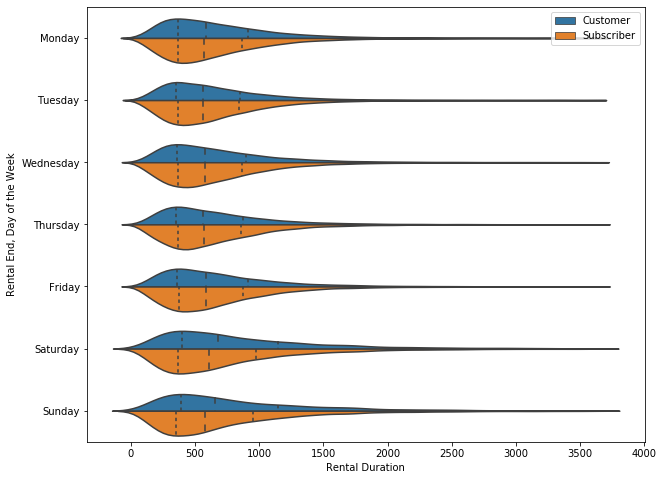

```python
plt.figure(figsize = [10, 8])

default_color = sb.color_palette()[0]
sb.violinplot(data = bike_lim, y = 'end_dayname', x = 'duration_sec', hue='user_type', split=True, inner='quartile', scale='count')
plt.xlabel('Rental Duration')
plt.ylabel('Rental End, Day of the Week')
plt.legend();
```

Like what we saw in the univariate exploration, subscribers have more rentals than customers, but similar rental duration during the days.  
Actually, customer rentals are a little bit longer looking at quartiles but if we look the actual difference in seconds they actually mean a difference of few minutes.

### Talk about some of the relationships you observed in this part of the investigation. Were there features that strengthened each other in terms of looking at your feature(s) of interest?

Plotting the geographical distribution of rentals during workdays and weekends strenghtened the hypotesis that rentals are made principally for commuting on Monday-Fridays. This makes sense looking also at the number of subscribers that rent a BayWheels bike: if i were a worker that everyday have to do the home-workplace route and viceversa (or from a different transport, like a train, to my workplace) i would certainly have a subscription.

### Were there any interesting or surprising interactions between features?

As said in the geographical analysis of the Customers/Subscribers it was surprising to see that in Oakland we have more customers than subscribers, probably due to the nature of those routes as previously illustrated.